# Automated Text Data Processing Techniques on Trouble Ticket for Enhancing Resolution Knowledge in Bigdata Perspective

Fauzy bin Che Yayah

November 11, 2015

# Abstract

*Trouble ticket system is always includes very rich data, but how to data-mining from is very challenging task.In this paper we apply the technique of data processing for the ease for the next stage of classification and prediction.On the other hand , we applied new technology of data mining by combining with the Bigdata elements for faster and achievable results.*

# Keywords

Data mining; data processing ; hadoop ; tickets data ; text processing

# Introduction

The trouble ticket system for telecommunication industries produced several thousand of records everyday. These records provide rich, accurate and complete for the system diagnostics and enhancing the customer experience by solving the problems. The live records stored inside the database of all levels of servers and replicated into the Enterprise Data Warehouse (EDWH) for data staging and shared among the departments via the credential and permission for different points of usage or use case. The data are coordinated and conserved for at least for five years minimum, which is enough for the analytics and data discovery purpose. The remaining more than five years of data will not be discarded and the archiving process will be applied for future reference. Because of the EDWH is optimized for storage, any heavily queries for analytics purpose in the system is not recommended which this activity will jeopardize the overall system performance.

# Related work

## Introduction of TTS

The trouble ticket system is considered as an assistant software which implements the Decision Support System (DSS) that manage and maintain lists of issues recorded by the customer support call center. The system contains a knowledge based containing the vital information for each subscribed customer, common resolution for most of the problems, and other such data. The ticket is the details of particular problem which contains the ticket status and other relevant data.

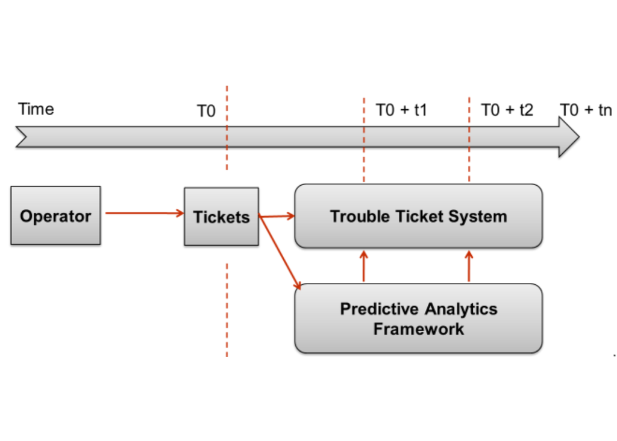

## Basic structure of trouble ticket data

The dataset of customer trouble ticket mainly comes from the trouble ticket system (TTS). The data set, then distributed into different levels of staging servers and other type database system at different levels of credential. The table below is a list of some fields from the trouble ticket table which mapped from the CTTS database :-

| Column Name | Column Type | Notes |
| --- | --- | --- |
| id | String | Generated ID by the system |
| created_dt | DateTime | Date of the trouble ticket creation |
| closed_dt | DateTime | Date of the trouble ticket closed |
| symp_err | String | Symptom error detected |
| cause_cat | String | Category Code define by the system |
| cause_code | String | Cause Code define by the system |
| res_code | String | Resolution Code define |
| desc | Text | Detail textual information such as |
|  |  | customer information, session status, |
|  |  | system status, network status , etc. |
|  |  | Cause Code define by the system |
| acc_name | String | Name of the customer |
| acc_num | String | Account number of the customer |
| package | String | Main package subscribed by the customers |
| zone | String | Product affected zone |
| …. | …. | …. |

\newpage

In summary , this table below is the sample of TTS records :-

[output not shown]

We identify the structure inside the TTS (*desc*) contains a free text form inside the description field. This is in need for search and analyze inside it. The data need to transform into something that can have a better understanding and more effective representation. A TTS description is fill-up by capturing from the customer call center or by the technician from the two major sources such as email and subsequent call from the customer.Thus, most of the data is not explicitly structured, it is also highly noisy (e.g, inconsistent formatting) and also very heterogenous (e.g., multiple language, such as Bahasa Melayu or English, system generated data, specific telecommunication term , abbreviation , acronyms and jargons),making it hard to analyze and search information from the raw data. We introduced an approach for automatically search for specific knowledge or topics from the collection of the free from text section (desc) inside the TTS.

# Techniques

Our elegant methodology automatically structuring free-from heterogenous textual data helps to identify the structural pattern specific pattern known to the call center of technician which helps them to speed up the tedious work manually searching and understanding the relevant data inside it. Below is the workflow for this methodology :-

- Acquiring with basic filtering TTS dataset from EDWH into Hadoop using Sqoop
- Applying index number for TTS dataset inside Hive
- Second filtering of TTS dataset
- Create a Document Term Matrix (DTM)
- Sparse Terms Removal
- Vectorization of TTS (VTTS)
- VTTS and DTM
- Training
- Testing
- Prediction

## Acquiring with basic filtering TTS dataset from EDWH into Hadoop using Sqoop

To acquire TTS dataset from the EDWH we need special operation using *Sqoop* components inside Hadoop into Hive compatible format. Hadoop is an open-source software framework for storing data and running applications on clusters of commodity hardware. Hive is a data warehouse infrastructure built on top of Hadoop for providing data summarization, query, and analysis.Sqoop is a tool designed to transfer data between Hadoop and relational database servers.

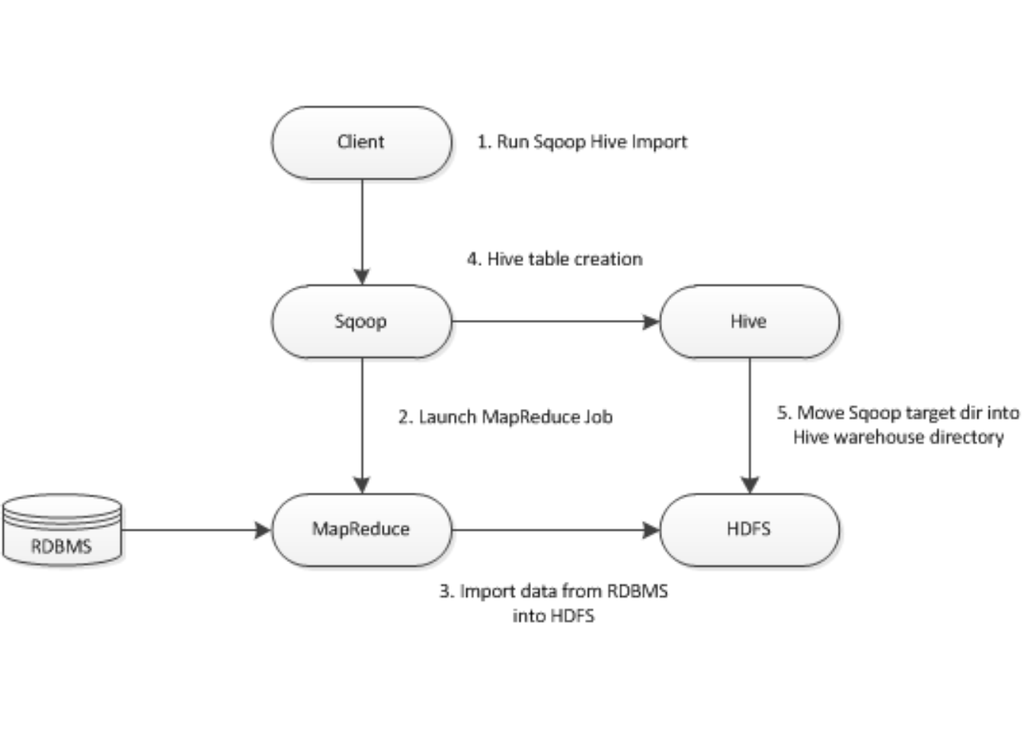

Sqoop basic syntax for importing dataset from TTS as follows :-

```
sqoop import --connect jdbc:[rdbms driver]:@[ip_address]:[port]/[db_name]
--username [username] --password [password]  --target-dir [temp_target]  --verbose
-e "select [field[1:n],REGEXP_REPLACE([desc_field_name],
'[^a-zA-Z0-9\\:\\@\\/\\#\\-]', ' ') " --m 1 --hive-table
[dbname_in_hdfs][tablename_inhdfs] --hive-import
--append --fields-terminated-by '\001'
--lines-terminated-by '\n' --hive-delims-replacement '';
```

Description of the syntax above as follows :-

[output not shown]

\newpage

To make, it is safe to resides into the Hive table, any special character set by `REGEXP_REPLACE` found during acquiring the dataset will be replaced with default delimiter `NULL` or empty char. this can be achieved by applying the `--hive-delims-replacement ''` and `REGEXP_REPLACE` `[^a-zA-Z0-9\\:\\@\\/\\#\\-]` inside the command line while sqoop is executed. The comparison images below shows the clean up results before and after applying the regular expression filtering :-

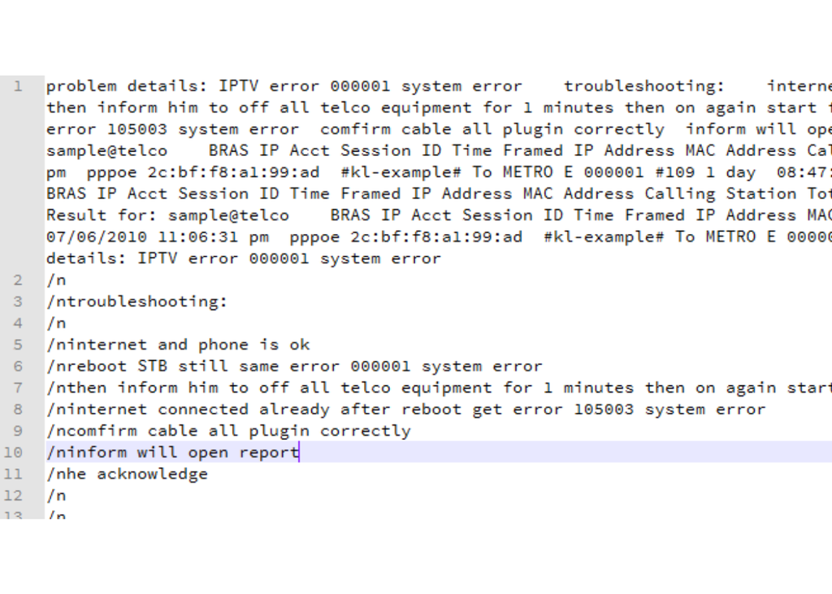

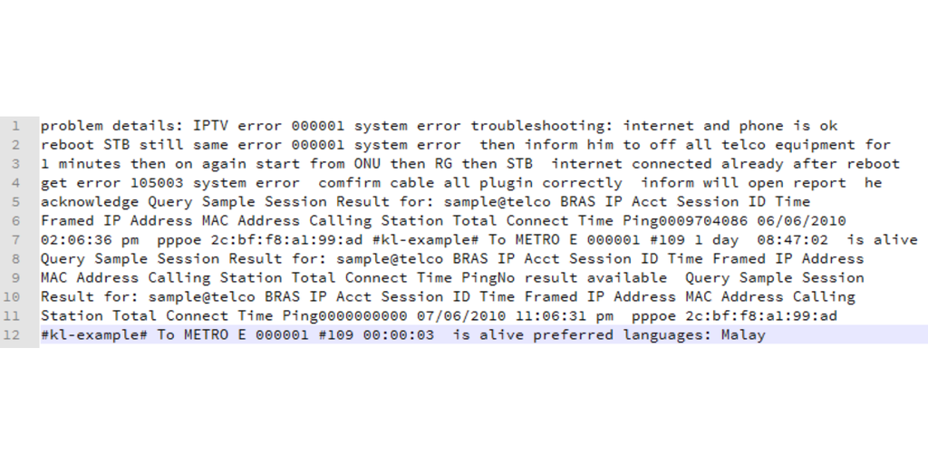

## Applying index number for TTS dataset inside Hive

Basic default Hive dataset doesn’t have any `autonumber` data type. The `autonumber` is very useful for primary key operation or for filter the records. We applied the the autonumber to the TTS dataset after the Sqoop operation finished. Because of the dataset which resides inside Hadoop is in Hive format , we need to use external jar file which is `hive-contrib-0.12.0-cdh5.1.2.jar` to create autonumber for the entire records. The jar file can be called by creating custom function as follows :-

```
drop function IF EXISTS row_sequence();
create function IF NOT EXISTS row_sequence()
returns BIGINT location 'lib/hive-contrib-0.12.0-cdh5.1.2.jar'
symbol='org.apache.hadoop.hive.contrib.udf.UDFRowSequence';
```

The rules applying the autonumber to the TTS dataset are to set by limits command inside the Hive-SQL. This is to ensure the dataset creation is reduced into single file inside the HDFS. Without the limit statement the Hive dataset files is chunked into the multiple split and the auto number sequence is set in 0 for each split or `single reducer`. This will cause the each records autonumber or it will be redundant. The Hive-SQL` command for this operation cab be achived by :-

```
drop table IF EXISTS tts_stage1;
create table IF NOT EXISTS tts_stage1 as select row_sequence() as id ,
* from [tts_table] limit 10000;
```

[output not shown]

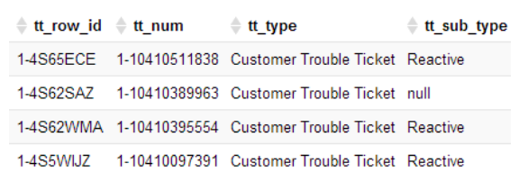

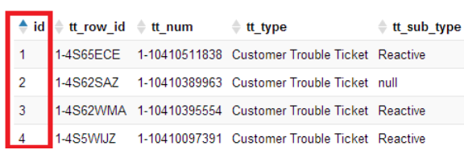

## Second filtering of TTS dataset

Since the dataset now are filled by autonumber `id`, now the record can be filtered by the `id` range . Tools such as RStudio which implements the R language statistical is used in this process. RStudio is capable to connect to various datasources including Hive. In this section , Open Database Connectivity(ODBC) for Hive need to be installed and configured. ODBC for Hive can be downloaded from the Cloudera website (http://www.cloudera.com/content/www/en-us/downloads/connectors/hive/odbc/2-5-12.html).

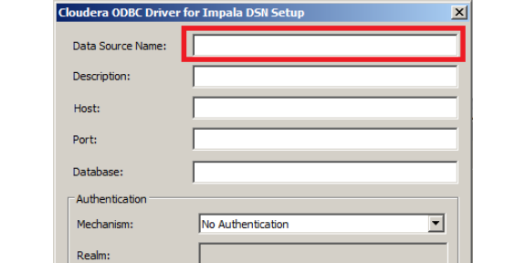

\newpage

Set the ODBC data source name *[dsn_name]* , the host address , the port number (default for *Impala* is 21050 ; *Hive* is 10000 ) , and the database name *[db_name]*. After that , test the ODBC connection.

After the ODBC System DSN name have been set , use RStudio create new `RScript` and implements the R code below for connnecting to Hive ODBC via RODBC package. Package RODBC implements ODBC database connectivity. (https://cran.r-project.org/web/packages/RODBC/vignettes/RODBC.pdf).The Rstudio can be downloaded from the Rstudio website. (https://www.rstudio.com/products/rstudio/download/).

- Sample RScript to implements RODBC as follows :-

  ```
  library(RODBC)
  conn <- odbcConnect(dsn="[dsn_name]", uid="[username]", pwd="[username]") #
  queryResult <- sqlQuery(conn, "select desc from [db_name].[hive_table_with_id]
  where id > 0 and id <= 10000 ")
  odbcClose(conn)
  ```

| R Script | Description |
| --- | --- |
| `library(RODBC)` | load the RODBC instance components |
| `conn <- odbcConnect(dsn="[dsn_name]"),` | Set the DSN name |
| `uid="[username]", pwd="[username]"` | set username and password |
| `sqlQuery(conn, "select desc from [hive_table_with_id]"` | Hive-SQL to filter the records |
| `"where id > 0 and id <= 10000"` | Condition to select the records |
| `odbcClose(conn)` | Cleans up and frees resources |

Five stages of data filteration need to be applied to clean up description text from the TTS information

[output not shown]

\newpage

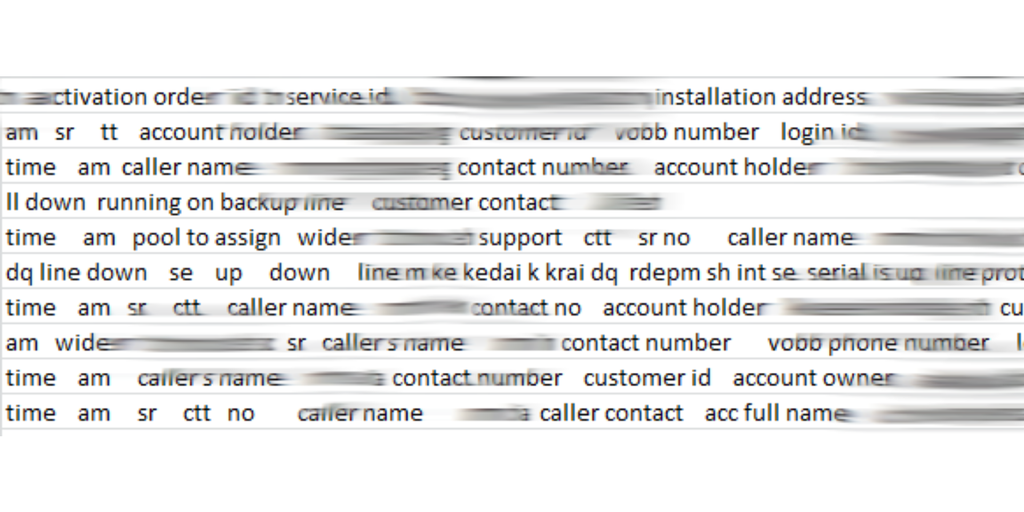

After appying the five steps of filteration , now the text description is suitable or the next stage of transformation which is Document Term Matrix (DTM) . DTM is a mathematical matrix that describes the frequency of terms that occur in a collection of documents. In this case the DTM will tied to each of the TTS records.

[figure not shown]

## Create a Document Term Matrix (DTM)

Document Term Matrix (DTM) is a matrix based dataset which describes the frequency of terms that occur inside collection of dataset especially the text based types. The DTM was spesifically designed to have rows and columns. Rows is correspond as related unique rows records (*documents*) and columns as the unique terms which exist inside the selective column dataset.

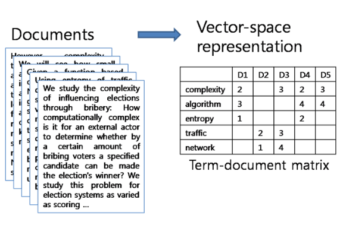

\newpage

The RScript below implements the Document Term Matrix function :-

```
      mach_corpus = Corpus(VectorSource(df_review$review))
      tdm = TermDocumentMatrix(mach_corpus,control = list(removePunctuation = TRUE,
      stopwords = c(stopwords("english")),
      removeNumbers = TRUE, tolower = TRUE))
      m <- as.matrix(tdm)
```

The description of R Script as follows :-

| R Script | Description |
| --- | --- |
| `Corpus(VectorSource(df_review$review))` | Representing and computing on `corpora`. |
| `TermDocumentMatrix` | Constructs or coerces to document-term matrix. |
| `c(stopwords("english"))` | Return various kinds of stopwords |
| `removeNumbers = TRUE` | Remove numbers from a text document |
| `as.matrix(tdm)` | Turn argument into a matrix |

Example of generated Document Term Matrix from TTS dataset as follows :-

Document Term Matrix of TTS

| tt_num | access | alarm | already | atpmgitn |
| --- | --- | --- | --- | --- |
| dfcc-1-12314522618 | 0 | 0 | 0 | 0 |
| dfcc-1-12314390988 | 0 | 0 | 0 | 0 |
| dfcc-1-12313258208 | 0 | 0 | 0 | 1 |
| dfcc-1-12312911038 | 0 | 0 | 0 | 0 |
| dfcc-1-12311810828 | 0 | 0 | 0 | 0 |
| dfcc-1-12311581758 | 0 | 0 | 0 | 0 |
| dfcc-1-12311375368 | 0 | 0 | 1 | 0 |
| dfcc-1-12310229828 | 0 | 1 | 1 | 0 |
| dfcc-1-12307977728 | 1 | 0 | 1 | 0 |
| dfcc-1-12306912058 | 0 | 0 | 0 | 0 |

```
## <<DocumentTermMatrix (documents: 20, terms: 103)>>
## Non-/sparse entries: 393/1667
## Sparsity           : 81%
## Maximal term length: 31
## Weighting          : term frequency (tf)
```

The information above summarize that the sparsity level is above 80% and removal of sparse term is needed for the next process . Some term like `access` , `alarm` , `already` , `atpmgitn` is low in frequency which proves all TTS `desc` sparsity level.

\newpage

## Sparse Terms Removal

Sparse Terms is the term which has low frequency . This can help the generalization process and prevent overfitting into the model. The example show the R Script with removal of 60% of the sparsity level inside the TTS `desc` field.

```
                tdm <- removeSparseTerms(tdm, sparse= 0.6 )
```

Sample of generated Document Term Matrix after removal of 60% sparsity term below :-

DTM removeSparseTerms

| tt_num | check | contact | downno | end |
| --- | --- | --- | --- | --- |
| dfcc-1-12314522618 | 3 | 1 | 1 | 2 |
| dfcc-1-12314390988 | 1 | 0 | 1 | 1 |
| dfcc-1-12313258208 | 0 | 0 | 0 | 0 |
| dfcc-1-12312911038 | 3 | 1 | 0 | 2 |
| dfcc-1-12311810828 | 0 | 0 | 0 | 0 |
| dfcc-1-12311581758 | 2 | 1 | 0 | 2 |
| dfcc-1-12311375368 | 0 | 0 | 1 | 1 |
| dfcc-1-12310229828 | 0 | 0 | 1 | 1 |
| dfcc-1-12307977728 | 0 | 0 | 0 | 1 |
| dfcc-1-12306912058 | 2 | 1 | 0 | 2 |

```
## <<DocumentTermMatrix (documents: 20, terms: 17)>>
## Non-/sparse entries: 220/120
## Sparsity           : 35%
## Maximal term length: 14
## Weighting          : term frequency (tf)
```

## Vectorization of TTS (VTTS)

To enable dataset for prediction data processing, we need to convert all the independent variables inside the TTS which is in factor format (*code status*) into numeric format. In this sample we select the course code as the sample for vectorize the dataset. This technique can be applied to all non-numeric formats of the other field inside the TTS dataset.

Sample TTS Cause Code

| cause_code |
| --- |
| other_rightwhentested |
| * disconnect |
| * disconnect in internal wirin |
| * earthing at internal wiring |
| * earthing problem |
| * far end |
| * high resistance in internal |
| * modem off/reset/reconfigure |
| * others (customer fault) |
| * others internal wiring |

## VTTS with DTM

# Experiments and results

# Acknowledgments

# References